# Cuisine Classification Pipeline

Salman Anwer

August 4th, 2019

## Introduction

In the era of Big Data, we often hear that, “information is the new oil”. This aphorism points to a key truth in the information saturated environment we find ourselves in: increasingly, information itself is a core source of revenue for many companies. But data without proper insight or analysis is not information. At worst, improperly analyzed data is misleading noise. At best, it clogs up data warehouses. What Big Data approaches have brought us is the ability to meaningfully turn this “lead” data with exponentially growing volume, velocity, and variety, into “liquid gold” information. But even this proper analysis has a catch; it must be completed and provided to customers with acceptably low latency so that customers can act on these informational insights before windows of opportunity close (Park 2019).

Among the many forms of data increasingly available to businesses is that of text documents. Text documents, be they reviews, emails, or news items provide a treasure trove of data that can be leveraged to automate or inform what was once painfully slow business processes done by hand. Here, the handmaiden of Big Data, Machine Learning, shows its value. Machine Learning approaches allow for automated insight discovery in a manner that surpasses more traditional algorithms in both speed and accuracy. An important aside here bears mentioning: the big caveat is that the quality of machine driven “learning” over some dataset is not implementation agnostic. Care must be taken in developing the right machine learning pipeline for the right problem. And so arises the job title of “Data Scientist”. That said, the marriage of Big Data and Machine Learning has certainly been a fruitful one with much promise.

### Problem Description

Documentation Classification, the problem that this project broadly tackles, is an old friend of many in Data Science. Residing at the intersection of both Machine Learning (ML) and Natural Language Processing (NLP), this problem is a well understood one that nonetheless has many domain constraint intricacies. While document classification can be done on small datasets in batch processes, Big Data approaches on top of this NLP + ML stack allow for the stream processing of a potentially enormous document corpus. Such an approach enables automated classification model maintenance and improvement which further streamlines business process that utilize the insights provided by document classification.

While document classification applications tend to have a technical angle such as spam or news topic classification (Holtes 2019), more “down to earth” business domains can benefit from this powerful ML powered tool as well. The food industry is one such domain. Like many other large and lucrative industries, the food industry has seen an explosion in information service companies that often rely on information aggregation and analysis to provide personalized and novel offerings to customers. From tailor-made meal subscriptions, to “wisdom of the crowd” powered macro-nutrient databases, to recipe sites with filters and recommender systems that more closely resemble Netflix than legacy-media recipe magazines, Big Data approaches to turning lead data into information gold are not limited only to suite and tie sectors.

This project tackles a problem of Document Classification in this more “down to earth” domain. Using a dataset provided by Yummly, a company that bills itself as a “personalized recipe recommender and search provider” (Lomas 2014), this project takes on the task of classifying a recipe’s cuisine of origin, given it’s comprising ingredients. Utilizing the Spark/Scala framework, this project will develop an automated ML pipeline scaffold for this problem that is both low latency and accurate, with future support for dynamic online model improvement.

## Dataset Exploration

The Yummly dataset (Yummly 2015) is relative straightforward as document datasets come. In this dataset, a document is a recipe, its multinomial classification is its cuisine of origin, and the recipe’s ingredients are the document terms.

Taking a peek at the dataframe representation of our dataset reveals a familiar structure:

```scala
+-----------+-----+--------------------+
|    cuisine|   id|         ingredients|
+-----------+-----+--------------------+
|      greek|10259|[romaine lettuce,...|
|southern_us|25693|[plain flour, gro...|
|   filipino|20130|[eggs, pepper, sa...|
|     indian|22213|[water, vegetable...|
|     indian|13162|[black pepper, sh...|
|   jamaican| 6602|[plain flour, sug...|
|    spanish|42779|[olive oil, salt,...|
|    italian| 3735|[sugar, pistachio...|
|    mexican|16903|[olive oil, purpl...|
|    italian|12734|[chopped tomatoes...|
+-----------+-----+--------------------+
only showing top 10 rows

root
 |-- cuisine: string (nullable = true)
 |-- id: long (nullable = true)
 |-- ingredients: array (nullable = true)
 |    |-- element: string (containsNull = true)
```

We can also see that our dataset has quite a large number of recipes and unique ingredients, with a decently large number of unique cuisine labels:

```scala
rawRecipieCount: Long = 39774
rawCuisineCount: Long = 20
rawIngredientCount: Long = 6714
```

Upon examining the dataset more closely however, we find some data impurity:

```scala
+-----------+-----+--------------------+--------------+
|    cuisine|   id|         ingredients|    ingredient|
+-----------+-----+--------------------+--------------+
|southern_us|13307|[sugar, custard, ...|braeburn apple|
|southern_us|22471|[granulated sugar...|braeburn apple|
|southern_us|45110|[radishes, choppe...|Braeburn Apple|
|southern_us|29894|[milk, baking pow...|braeburn apple|
|     indian|18062|[tomato paste, bo...|Braeburn Apple|
+-----------+-----+--------------------+--------------+
```

Here we see some feature impurity on the terms or ingredients given in the raw dataset. The ingredient Braeburn Apple is showing up as two separate entities or features in the raw data, one for “Braeburn Apple”, and one for “braeburn apple”.

After cleaning this impurity (ensuring all ingredients in the dataset are represented uniformly), we re-examine our dataset summary:

```scala
cleanedRecipieCount: Long = 39774
cleanedCuisineCount: Long = 20
cleanedIngredientCount: Long = 6703
```

Our unique ingredient count is now a bit smaller, but uniform encodings of our features will ensure better results when we turn to applying ML techniques. Furthermore, we have just enough documents to properly learn classification models on the dataset. The rule of thumb often given is that, a dataset must contain 5 to 10-fold more documents than the number of features for a document classification model to be accurately learned (Thapliyal 2018).

Next, we take a look at our dataset’s distribution of document class or cuisine of origin:

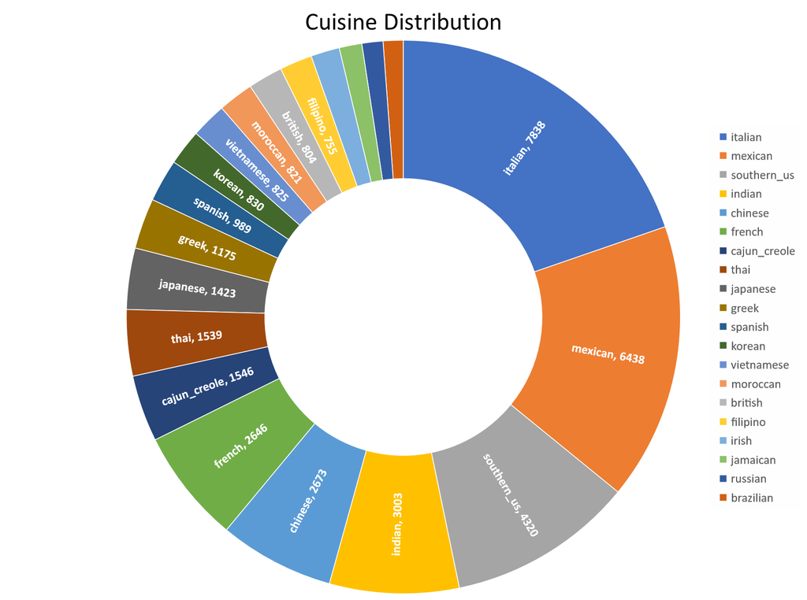

We see from the above graph that the load or distribution of document classes in our dataset is not ideal. However, the distribution isn’t weighted overwhelmingly to one class or the other. If this was the case, there would be major statistical issues with applying ML to such a dataset. Ultimately, there will be bias towards the weightier classes like “mexican” or “italian”, but we will show that good classification performance can still be reached even in this less than ideal dataset.

Lastly, we look at our dataset’s distribution of features or ingredients:

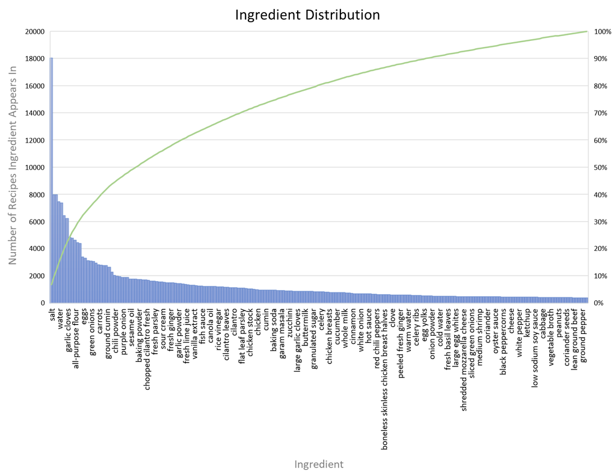

In the above graph, the cumulative distribution is represented by the green line with its axis on the right, while the associated counts (the number of recipes an ingredient appears in) of each ingredient is on the left axis. Here we see a classic Pareto distribution of ingredients, with an exponential drop off from the number one ingredient: salt. We also see a massively long tail, and this long tail is under-represented as the ingredients shown are only the top 3% of ingredients. Still, as we claimed above, good document classification performance will be found on this dataset. In fact, we will exploit our feature distribution for the desired low latency of learning our classification model.

### Preprocessing Techniques

Given the graciously straight forward nature of the Yummly dataset, there was only minor preprocessing of the data that needed to be done prior to feeding it into our ML pipeline.

1. The dataset was provided in a raw JSON file:  
   The dataset format makes sense given the web first stance taken by Yummly. Spark provides native support for JSON formatted datasets to be converted into the dataframe format that is so integral to contemporary data science work. However, the provided dataset is given as a raw JSON file. Spark cannot directly take a raw JSON file as input for a dataframe. First, the dataset has to be read in as a raw text file to the Spark Dataset format. After this, standard Spark parsing from JSON Dataset to Dataframe was applied.
2. As discussed above, the dataset contained feature impurities:  
   The same ingredients (“braeburn apple”, “Braeburn Apple”) under slightly different encodings was found in the dataset. The performance of ML models trained on this impure dataset would suffer due to this impurity. To offset this, we explode the dataset so that every recipe’s ingredient list is flattened, and then pass all ingredient terms to a lowerCase Mapper.

Following these two simple preprocessing techniques, the dataset is ready for our ML pipeline.

## Proposed Solution

As a reminder, we are targeting a solution to our document classification task with an automated ML pipeline that is accurate, low latency, and capable of online dynamic model improvement and selection. Thus, we need a pipeline that is no-nonsense to meet our low latency requirement, whilst retaining enough complexity to accurately classify our large and diverse corpus.

Towards this, we devised a pipeline that was relatively streamlined. First, we take the input dataset and ensure data encoding uniformity. This is the stage where a notion of online or streaming data model learning can be brought in. Next, we prepare the dataset for learning by labeling document classes (cuisines) with suitable machine readable labels. Then, we vectorize the given features (ingredients) so that each document (recipe) is associated with a count vector of its comprising ingredients that has a dimension equal to the number of unique ingredients in the corpus (a highly sparse vector). We then scale these vectors so that frequently occurring features (ingredients) in our corpus are down regulated. Following this, we feed our uniformed and scaled dataset into a One vs. Rest Linear Support Vector Machine model to learn our desired classification decision boundaries. For the hyper-parameters used in our SVM model, we use a Grid Search approach to specify a range of possible optimal hyper-parameters. And finally, again with respect to our latency requirement, we utilize a randomized Train Validation split on our learned models to pick out the model on our parameter grid with highest accuracy.

### Methods

At almost every step in our proposed solution, there are a multitude of suitable alternatives. Below we will explain our decision reasoning for each method used, as well as summarize the method utilized.

1. Data encoding uniformity:  
   There are certainly many approaches to ensuring that the data in our dataset is encoded uniformly. We chose to simply apply a universal lowercase map to each of our ingredient features, but one could have just as easily chosen to apply a universal uppercase map. Both approaches would have the same effect. A hashing approach, or a regex approach, or any number of more complicated methods could have been used. Ultimately however, such complicated approaches would only add overhead without returning much by the way of classification performance.
2. Class labeling: A simple string to index approach was taken in our solution. This is essentially a hash map of a the document class, a string, to an index. Here too, more complicated approaches could have been taken. Here again, there would be no improved return on classification performance. The point will not be belabored.
3. Vectorizing features: Here is one of the first impactful decision points. In our proposed solution we chose to use the Spark provided, “CountVectorizer” approach to transform our ingredient features into a machine readable vector. The CountVectorizer approach walks through the entirety of the dataset and assigns each unique ingredient a index number, and tallies the number of occurrences of each ingredient term in each recipe document. It simply takes a input our dataset, and the number of unique ingredient terms in our corpus. An alternative here to using CountVectorizer would be to use a hashing approach, such as the Spark provided HashingTF. This approaches utilizes the hashing trick with a MurmurHash 3 implementation. The HashingTF approach however, requires an additional axis on our parameter Grid Search, which is extremely expensive given its low performance return. This in addition to that fact that, in testing our solution, HashingTF consistently resulted in degraded model performance led us to utilizing CountVectorizer for feature vectorization.
4. Scaling feature vectors: Using the raw feature vectors provided by step 3 is workable, but ultimately will impact the learned model’s accuracy. This is due to the fact that certain ingredients (such as “salt”) appear in a majority of recipe documents without providing much in terms of information gain. Such terms approach becoming stop-words, but they may offer some information gain. An unscaled document feature vector then, can often lead to biased models. There are many approaches to scaling a document’s feature vector, but one method that has become ubiquitous due to its power and simplicity is that of term frequency-inverse document frequency (TF-IDF) scaling (Wu et al. 2008). TF-IDF scaling simply scales a document term count by its inverse document frequency:
   $$f_{t, d} \cdot \log(\frac{N}{n_t})$$
   Where $f_{t, d}$ is the count of the term in a document, $N$ is count of documents in the corpus, and $n_t$ is the number of documents the term appears in. Although, even within TF-IDF there are multiple approaches of calculating term frequency and inverse document frequency, the general approach allows for quasi-stop-word-removal (by down scaling terms with little information gain) without expert domain knowledge. As an aside, this is one reason stop-word removal was not done on this dataset (a generally used tool in the document classification toolkit). Alternative approaches, such as pure stop-word removal or embeddings, could have been taken here instead of TF-IDF. Given the lack of expert domain knowledge and to retain a low latency in model learning and selection, TF-IDF was considered the best choice for feature scaling.
5. ML Classifier We now reach the most important decision point in our proposed solution. The choice of Machine Learning model, the hyper-parameters used in that model, and the validation used to pick the best model are some of the more important decision a Data Scientist makes during model creation.
   1. Learning Model:
      Our proposed solution includes the use of a Linear Support Vector Machine (LSVM) made famous by Vladimir Vapnik, for the base ML learning model (Boser, Guyon, and Vapnik 1992). This approach handles the task of supervised learning by constructing hyperplanes or decision boundaries between feature data-points of binary classes with maximum margin. This can be done with a so called “hard-margin”, where no data-points can be misclassified, or a “soft-margin” with a regularization term that allows for some data-points to be acceptably misclassified. Functionally this is given by:
      $$[\frac{1}{n} \sum_{i=1}^{n}\max(0, 1 - y_{i}(\vec{w} \cdot \vec{x_i} - b))] + \lambda {||\vec{w}||}^2$$
      Where $\max(0, 1 - y_{i}(\vec{w} \cdot \vec{x_i} - b))$ is referred to as the “hinge-loss” function, $\lambda$ is the regularization parameter of the soft-to-hard margin (smaller values approach a hard margin [the linearly seperable case]), $n$ is the max number of iterations, $(y_{i}, \vec{x_i})$ refer to a data-point in our dataset, $b$ is the margin of the decision hyperplane to boundary data-points, and $\vec{w}$ is the current decision hyperplane. We used the Spark provided implementation of the LSVM model “LinearSVC”, which optimizes the hinge-loss function using the OWL-QN optimizer (implemented in Breeze) which is an optimization algorithm that prioritizes limited memory use (Andrew and Gao 2007). Furthermore, the Spark implementation utilizes L2 or Ridge Regression regularization for the penalty term in the above loss function, with no kernel trick support. This approach was used for a few reasons. One, the current science indicates that the simpler the learning model, the better suited it is for Document Classification purposes (Holtes 2019). We compared the various “simple” supervised learning models implemented in Spark (Naive Bayes, Logistic Regression, Decision Trees) and found that LSVM performed the best when weighted by our latency requirement. In a test with untuned models, Logistic Regression came closest, but given the simplicity and power of LSVM we chose that approach. Additionally, the use of L2 regularization in the chosen LSVM approach allowed full exploitation of the sparsity of our dataset (L1 regularization, or Lasso regularization effectively trims sparse feature vectors) to learn decision hyperplanes quickly. Kernel tricks were also not needed as the high dimensionality of our dataset meant that we didn’t need to “lift” our feature vectors into higher dimensions to find good decision hyperplanes. This is further supported by the LibLinear project which notes that, in tasks like document classification where the number of data instances (or documents) are on similar orders of magnitude as the feature vector dimensions themselves, Linear SVM can be much faster than kernel trick SVMs while maintaining similar accuracy (Fan et al. 2008). Finally, on top of this well-suited LSVM base learning model, we utilized a One vs. Rest (OVR) classifier to adapt the binary classification property of SVM’s into multinomial case. This approach runs the model learning LSVM for each of our 20 target cuisine classes, with each iteration setting the chosen cuisine class as the positive class and all other classes as the negative class. An alternative was also faced here, in that a One vs. One (OVO) approach could have been used. Again though, due to the low latency target, OVR was chosen over OVO.
   2. Hyper-parameter tuning:  
      We made use of a Grid Search approach for automated hyper-parameter tuning. Keeping the maximum iterations held constant for ensured low latency, we used a 5x5 grid of potential hyper-parameters to tune for over tolerance (change in loss function at which learning will cease), and the L2 regularization parameter. The Grid Search approach entails evaluating a model trained on some point of the grid on some chosen metric at each point of the grid. Keeping the target latency in mind, the grid was kept relatively small. Finally, the simple metric of accuracy was used to evaluate models as dataset was not egregiously unbalanced. An alternative here could have been Bayesian Optimization for hyper-parameter tuning. This approach is cutting edge and promises to massively reduce the cost of hyper-parameter tuning. It essentially works in the following way. First, a hyper-parameter prior distribution is constructed randomly or using some domain understanding. Then, utilizing Bayes Theorem, and an iterative process, a posterior distribution is increasingly refined till it converges (Frazier 2018). While this approach is exciting and promising, a sufficiently stable implementation could not be found for the Spark/Scala framework.
   3. Validation:  
      Finally, we have the actual model validation, which we use on top of the grid search approach to automate the finding of a model with optimal hyper-parameters. Given the possibly multiplicative nature of this step, validation can be extremely expensive. To mitigate this expense, our solution uses a randomized Training Validation approach over the slightly more common, but more costly alternative, Cross Validation. Randomized training validation simply executes a one shot random test-train split on the given dataset along some given ratio (1:4, test to train in our implementation), uses the training set for learning, and the withheld test set for scoring the learned model (as mentioned above, we used accuracy). While Cross Validation is considered more robust in accurately picking a best model, it was prohibitively costly even at just 3-folds. Moreover in testing, randomized Training Validation was found to reach almost exactly as the same performance as low fold Cross Validation. Thus, Training Validation was chosen to meet the low latency requirement.

### Related Work

Given that this dataset was derived from Kaggle, there were many interesting solutions others discussed or sketched on the Kaggle page. Some approached the problem using the old school approach of document classification, using the word2Vec model of embeddings and Logistic Regression, while others sketched more complex solutions using Convolutional Neural Networks. There was a host of alternative approaches to our Yummly dataset with the most promising being the simpler approaches. In fact, a similar approach to ours was also found, however it differed along some core properties. Like many others on the Kaggle competition, many of the related approaches for this dataset involved Python and the much beloved SciKit-Learn package. While there is nothing inherently wrong with such an approach, for our requirement of low latency, yet accurate, with ease of extension to automated online dynamic model selection, this approach would not work. The more complex approaches, while theoretically interesting, are overkill for the document classification task. Especially given the industry understanding that simpler models are better for document classification, there is no reason to trade complexity for similar performance.

## Results

At this point, we have teased the performance of our solution for too many pages. Without further teasing, a broad summary of the results of our approach are given below.

| Accuracy | Weighted Precision | Weighted Recall | Weighted F-Measure | Weighted FPR |
| --- | --- | --- | --- | --- |
| 0.900 | 0.899 | 0.900 | 0.898 | 0.011 |

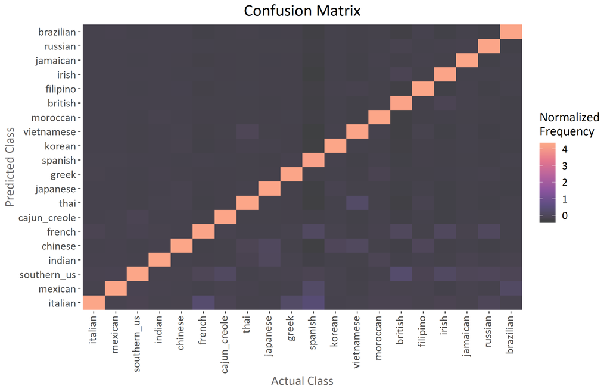

These results were achieved with the OVR LSVM best model, trained with the following parameters:

| Max Iterations | Regularization | Tolerance |
| --- | --- | --- |
| 20 | 0.0 | 1E-4 |

And finally, a sampling of the more granular results. For full results see the Project directory.

| Label | Cuisine | Precision |  | Label | Cuisine | Recall |  | Label | Cuisine | F-Measure |
| --- | --- | --- | --- | --- | --- | --- | --- | --- | --- | --- |
| 1 | mexican | 0.947 |  | 1 | mexican | 0.964 |  | 1 | mexican | 0.955 |
| 8 | japanese | 0.944 |  | 3 | indian | 0.959 |  | 3 | indian | 0.942 |
| 11 | korean | 0.928 |  | 0 | italian | 0.948 |  | 0 | italian | 0.926 |
| 3 | indian | 0.925 |  | 4 | chinese | 0.939 |  | 11 | korean | 0.920 |
| 15 | filipino | 0.919 |  | 11 | korean | 0.913 |  | 4 | chinese | 0.918 |
| 7 | thai | 0.916 |  | 13 | moroccan | 0.906 |  | 13 | moroccan | 0.910 |
| 13 | moroccan | 0.914 |  | 2 | southern_us | 0.904 |  | 7 | thai | 0.906 |
| 17 | jamaican | 0.906 |  | 7 | thai | 0.897 |  | 17 | jamaican | 0.901 |
| 0 | italian | 0.905 |  | 17 | jamaican | 0.895 |  | 8 | japanese | 0.891 |
| 9 | greek | 0.902 |  | 6 | cajun_creole | 0.876 |  | 6 | cajun_creole | 0.881 |
| 4 | chinese | 0.897 |  | 9 | greek | 0.860 |  | 2 | southern_us | 0.880 |
| 14 | british | 0.892 |  | 8 | japanese | 0.843 |  | 9 | greek | 0.88 |
| 19 | brazilian | 0.890 |  | 15 | filipino | 0.838 |  | 15 | filipino | 0.877 |
| 6 | cajun_creole | 0.887 |  | 19 | brazilian | 0.816 |  | 19 | brazilian | 0.851 |
| 12 | vietnamese | 0.881 |  | 12 | vietnamese | 0.805 |  | 12 | vietnamese | 0.841 |
| 10 | spanish | 0.862 |  | 5 | french | 0.804 |  | 16 | irish | 0.820 |
| 16 | irish | 0.861 |  | 16 | irish | 0.783 |  | 5 | french | 0.812 |
| 2 | southern_us | 0.858 |  | 18 | russian | 0.779 |  | 14 | british | 0.801 |
| 5 | french | 0.820 |  | 14 | british | 0.728 |  | 18 | russian | 0.790 |
| 18 | russian | 0.800 |  | 10 | spanish | 0.662 |  | 10 | spanish | 0.749 |

### Analysis

From the above results we can see that our solution produces some strongly accurate results, with that target low latency met. Training and model selection was accomplished in under 1 hour on a modest AWS cluster. Given the balance of cuisine classes seen in the Fig 1. Cuisine Distribution, the near universal strength of classification is a testament to the strength of the LSVM learning model for document classification tasks. While the granular results showed some faltering in classifying certain classes, more balanced and larger datasets will mitigate this weakness.

## Conclusion

This project showed an effective approach to document classification in the domain of food knowledge that, due to the underlying framework, is both quick, accurate, and easily extensible to support an online automated model selection pipeline that utilizes a dynamically growing dataset using the Spark Streaming framework. Furthermore, in the future, Bayesian Optimization can be fit into model selection instead of a Grid Search approach to further decrease the latency in model selection.

## References

Andrew, Galen, and Jianfeng Gao. 2007. “Scalable Training of L1-Regularized Log-Linear Models.” In *Proceedings of the 24th International Conference on Machine Learning*, 33–40. ICML ’07. New York, NY, USA: ACM. doi:10.1145/1273496.1273501.

Boser, Bernhard E., Isabelle M. Guyon, and Vladimir N. Vapnik. 1992. “A Training Algorithm for Optimal Margin Classifiers.” In *Proceedings of the 5th Annual Acm Workshop on Computational Learning Theory*, 144–52. ACM Press.

Fan, Rong-En, Kai-Wei Chang, Cho-Jui Hsieh, Xiang-Rui Wang, and Chih-Jen Lin. 2008. “LIBLINEAR: A Library for Large Linear Classification.” *J. Mach. Learn. Res.* 9 (June). JMLR.org: 1871–4. http://dl.acm.org/citation.cfm?id=1390681.1442794.

Frazier, Peter I. 2018. “A Tutorial on Bayesian Optimization.” *arXiv Preprint arXiv:1807.02811*.

Holtes, Grant. 2019. “Surprising Findings in Document Classification.” *Medium*. Towards Data Science. https://towardsdatascience.com/surprising-findings-in-document-classification-7a79e30f1666.

Lomas, Natasha. 2014. “Yummly Takes Its Recipe Discovery Platform International with U.K. Site & iOS App Launch.” *TechCrunch*. TechCrunch. https://techcrunch.com/2014/01/15/yummly-uk/.

Park, Hyoun. 2019. “KDnuggets.” *KDnuggets Analytics Big Data Data Mining and Data Science*. Amalgam Insights. https://www.kdnuggets.com/2019/07/death-big-data-multi-cloud-era.html.

Thapliyal, Manish. 2018. “Document Classification Using Machine Learning.” *Medium*. MLRecipies. https://medium.com/mlrecipies/document-classification-using-machine-learning-f1dfb1171935.

Wu, Ho Chung, Robert Wing Pong Luk, Kam Fai Wong, and Kui Lam Kwok. 2008. “Interpreting Tf-Idf Term Weights as Making Relevance Decisions.” *ACM Transactions on Information Systems (TOIS)* 26 (3). ACM: 13.

Yummly. 2015. “What’s Cooking?” *Kaggle*. https://www.kaggle.com/c/whats-cooking/data.